# Title: Impact of Earthquakes from 1970 to 2020

## Team members: Alan Chen and Samuel Chen

## Motivation:

Within the past decade, Earth has experienced more destructive severe natural disasters. Earthquakes and other natural disasters have increased in frequency over the past decade. Earthquakes are also known as a natural disaster that can cause additional destruction by triggering other disasters like tsunamis and bolcano eruptions. We will investigate earthquakes records from the past in this project.

This project aims to analyze trends and the impacts related to earthquakes between the years 1970 to 2020. We chose to analyze this time interval since research had found that climate change had an effect on weather patterns. This time interval is recent enough to get a general idea of Earth’s current seismic activity and old enough to create a regression model for modern seismic activity. In this project we will investigate:  
The relationships between frequency and locations of earthquakes  
Magnitude and damage (in Millions of $)  
Magnitude and injuries  
Magnitude and deaths  
Which countries have the most earthquakes  
The number of earthquakes per year.

As climate change continues to be a pressing problem for the future, data analysis of this project will contribute to predictions of Earthquake frequency, severity, and locations so we can identify countries which are most vulnerable to earthquakes and project how earthquakes could look like in the future.

## Data Set Selection:

The dataset that we selected to analyze for this project is the Earthquake data set from the National Geophysical Data Center (NGDC) which is a subdivision of the National Oceanic and Atmospheric Administration. We chose this data set since it is a credible source since it is regulated by the US government. This data set contained records dating back to 2586 BC to the present. We recognized that the present seismic landscape to be different since then and selected the time interval between 1970 till the present.

```python
import pandas as pd
import numpy as np
import matplotlib as mpl
import matplotlib.pyplot as plt
from sklearn import linear_model
from sklearn.model_selection import train_test_split
```

```python
# first we import the entire data
complete_data_set = pd.read_csv('earthquake.csv', delimiter=',')

# drop 0th row because it's the column names
complete_data_set = complete_data_set.drop(0)
# take a look
complete_data_set
```

|  | Search Parameters | Year | Mo | Dy | Hr | Mn | Sec | Tsu | Vol | Location Name | Latitude | Longitude | Focal Depth (km) | Mag | MMI Int | Deaths | Death Description | Missing | Missing Description | Injuries | Injuries Description | Damage ($Mil) | Damage Description | Houses Destroyed | Houses Destroyed Description | Houses Damaged | Houses Damaged Description | Total Deaths | Total Death Description | … |
| --- | --- | --- | --- | --- | --- | --- | --- | --- | --- | --- | --- | --- | --- | --- | --- | --- | --- | --- | --- | --- | --- | --- | --- | --- | --- | --- | --- | --- | --- | --- |
| 1 | NaN | 1970.0 | 1.0 | 4.0 | 17.0 | 0.0 | 40.2 | NaN | NaN | CHINA: YUNNAN PROVINCE; VIETNAM: HANOI | 24.100 | 102.500 | 31.0 | 7.8 | 10.0 | 10000.0 | 4.0 | NaN | NaN | NaN | NaN | NaN | 3.0 | NaN | 3.0 | NaN | 3.0 | 10000.0 | 4.0 | … |
| 2 | NaN | 1970.0 | 1.0 | 10.0 | 12.0 | 7.0 | 8.6 | 2019.0 | NaN | PHILIPPINES: MINDANAO | 6.800 | 126.700 | 73.0 | 7.6 | 6.0 | NaN | NaN | NaN | NaN | NaN | NaN | NaN | NaN | NaN | NaN | NaN | NaN | NaN | NaN | … |
| 3 | NaN | 1970.0 | 2.0 | 5.0 | 22.0 | 5.0 | 58.3 | NaN | NaN | PHILIPPINES: LUZON, ROMBLON I; TABLAS I: ODI... | 12.600 | 122.100 | 11.0 | 7.1 | NaN | 3.0 | 1.0 | NaN | NaN | NaN | 2.0 | NaN | 2.0 | NaN | NaN | NaN | NaN | 3.0 | 1.0 | … |
| 4 | NaN | 1970.0 | 2.0 | 14.0 | 11.0 | 17.0 | 16.1 | NaN | NaN | PERU: PANAO,CHACLLA,QUERO,AYLLAMARCA,LA LINDA | -9.900 | -75.600 | 35.0 | 5.4 | 9.0 | 12.0 | 1.0 | NaN | NaN | NaN | NaN | NaN | 3.0 | NaN | 3.0 | NaN | NaN | 12.0 | 1.0 | … |
| 5 | NaN | 1970.0 | 3.0 | 11.0 | 22.0 | 38.0 | 34.6 | 3309.0 | NaN | ALASKA: ANDREANOF ISLANDS | 57.500 | -153.900 | 29.0 | 6.0 | 5.0 | NaN | NaN | NaN | NaN | NaN | NaN | NaN | 1.0 | NaN | NaN | NaN | NaN | NaN | NaN | … |
| ... | ... | ... | ... | ... | ... | ... | ... | ... | ... | ... | ... | ... | ... | ... | ... | ... | ... | ... | ... | ... | ... | ... | ... | ... | ... | ... | ... | ... | ... | … |
| 2142 | NaN | 2020.0 | 8.0 | 18.0 | 0.0 | 3.0 | 48.0 | NaN | NaN | PHILIPPINES: MASBATE | 12.021 | 124.123 | 10.0 | 6.6 | 7.0 | 2.0 | 1.0 | NaN | NaN | 50.0 | 1.0 | 0.57 | 1.0 | 138.0 | 3.0 | 1167.0 | 4.0 | 2.0 | 1.0 | … |
| 2143 | NaN | 2020.0 | 10.0 | 19.0 | 20.0 | 54.0 | 39.0 | 5755.0 | NaN | ALASKA | 54.608 | -159.655 | 33.0 | 7.6 | 8.0 | NaN | NaN | NaN | NaN | NaN | NaN | NaN | NaN | NaN | NaN | NaN | NaN | NaN | NaN | … |
| 2144 | NaN | 2020.0 | 10.0 | 30.0 | 11.0 | 51.0 | 27.0 | 5757.0 | NaN | GREECE: SAMOS; TURKEY: IZMIR | 37.918 | 26.790 | 21.0 | 7.0 | 8.0 | 117.0 | 3.0 | NaN | NaN | 1054.0 | 4.0 | 400.00 | 4.0 | NaN | 2.0 | NaN | 4.0 | 118.0 | 3.0 | … |
| 2145 | NaN | 2020.0 | 12.0 | 27.0 | 21.0 | 39.0 | 14.0 | 5760.0 | NaN | CHILE: OFF COAST CENTRAL | -39.343 | -74.990 | 10.0 | 6.7 | 5.0 | NaN | NaN | NaN | NaN | NaN | NaN | NaN | NaN | NaN | NaN | NaN | NaN | NaN | NaN | … |
| 2146 | NaN | 2020.0 | 12.0 | 29.0 | 11.0 | 19.0 | 54.0 | NaN | NaN | BALKANS NW: CROATIA: PETRINJA | 45.422 | 16.255 | 10.0 | 6.4 | 9.0 | 8.0 | 1.0 | NaN | NaN | 36.0 | 1.0 | 1000.00 | 4.0 | 1500.0 | 4.0 | 46000.0 | 4.0 | 8.0 | 1.0 | … |

2146 rows × 39 columns

## Tidying Data:

#### Raw Data Set

Initially the data that we used had a total of 39 columns as shown above. Many of the columns have ‘NaN’ as a value for an earthquake entry. We decided to remove those columns because all those missing values would not be helpful with answering our questions about earthquakes. Furthermore, there are some columns that contain information that are not required for us to complete our investigation. For example, the longitude and latitudes of these earthquakes are not needed to answer our investigation questions listed above.

When tidying the data we found that some of the columns were repeated columns. Examples include ‘Deaths’ and ‘Total Deaths’ columns, ‘Missing’ and ‘Total Missing’, ‘Injuries’ and ‘Total Injuries’, and ‘Damage’ and ‘Total Damage’. To resolve this we decided to just use one of these columns to represent that parameter. Unfortunately, a significant amount of these values were still missing. Instead we used the Description columns to measure those parameters since there was a much higher turnout in the raw data set.

To clean up the columns for the datetime, we combined the "Year", “Mo", "Dy", "Hr", "Mn", "Sec" columns.

The remaining columns, Mag and Location Name, from the raw data set were left untouched. One additional column that we made was the country column. This was created using the Location Name column. Since that column had the format “Country, City” we created that column by getting the first portion of the Location Name column.

We tidied the data set based on the columns that we need to answer the questions in our investigation. The columns that we have are:

1) Datetime - Represents the date and the time an earthquake occured  
2) Location Name - Lists the City and Country the earthquake occurred  
3) Country - List the country the earthquake occurred  
4) Mag - Magnitude of the earthquake  
5) Damage Description - Scales 0 - 4 to measure the approximate amount of damage done in millions  
0 - indicates No damage done  
1 indicates Limited damage(approximately less than \$1 million)<br/> &nbsp; &nbsp;&nbsp;&nbsp;&nbsp;&nbsp;&nbsp;2 indicates moderate damage (approximately \$1-\$5 million)<br/> &nbsp; &nbsp;&nbsp;&nbsp;&nbsp;&nbsp;&nbsp;3 indicates severe damage (approximately \$5-\$25 million)<br/> &nbsp; &nbsp;&nbsp;&nbsp;&nbsp;&nbsp;&nbsp;4 indicates Extreme damage(approximately \$25+ million)

6) Injury Description - Scales 0 - 4 to measure the approximate amount of injuries reported  
0 indicates None  
1 indicates Few (1-50 injuries)  
2 indicates Some (51-100 injuries)  
3 indicates Many (101 - 1000 injuries)  
4 indicates Very Many (over 1000 injuries)

7) Deaths Description- The number of deaths listed  
0 indicates None  
1 indicates Few (1-50 Deaths)  
2 indicates Some (51-100 Deaths)  
3 indicates Many (101 - 1000 Deaths)  
4 indicates Very Many (over 1000 Deaths)

```python
# Tidy data: re-organize time to a single column

# fill missing time data as 0
time_data = complete_data_set[['Year', 'Mo', 'Dy', 'Hr', 'Mn', 'Sec']].fillna(0)
print(time_data.head(5))

# convert type to int
time_data = time_data.astype('int64')

# combine all time-related data into the 'Datetime' column
time_data['Datetime'] = time_data.apply(lambda row: f"{row['Year']}-{row['Mo']:02d}-{row['Dy']:02d} {row['Hr']}:{row['Mn']:02d}:{row['Sec']:02d}", axis = 1)
# change that column type to datetime
time_data['Datetime'] = pd.to_datetime(time_data['Datetime'], format = "%Y-%m-%d %H:%M:%S")
print(time_data.dtypes)
time_data.head(10)
```

```
     Year   Mo    Dy    Hr    Mn   Sec
1  1970.0  1.0   4.0  17.0   0.0  40.2
2  1970.0  1.0  10.0  12.0   7.0   8.6
3  1970.0  2.0   5.0  22.0   5.0  58.3
4  1970.0  2.0  14.0  11.0  17.0  16.1
5  1970.0  3.0  11.0  22.0  38.0  34.6
Year                 int64
Mo                   int64
Dy                   int64
Hr                   int64
Mn                   int64
Sec                  int64
Datetime    datetime64[ns]
dtype: object
```

|  | Year | Mo | Dy | Hr | Mn | Sec | Datetime |
| --- | --- | --- | --- | --- | --- | --- | --- |
| 1 | 1970 | 1 | 4 | 17 | 0 | 40 | 1970-01-04 17:00:40 |
| 2 | 1970 | 1 | 10 | 12 | 7 | 8 | 1970-01-10 12:07:08 |
| 3 | 1970 | 2 | 5 | 22 | 5 | 58 | 1970-02-05 22:05:58 |
| 4 | 1970 | 2 | 14 | 11 | 17 | 16 | 1970-02-14 11:17:16 |
| 5 | 1970 | 3 | 11 | 22 | 38 | 34 | 1970-03-11 22:38:34 |
| 6 | 1970 | 3 | 14 | 1 | 51 | 44 | 1970-03-14 01:51:44 |
| 7 | 1970 | 3 | 23 | 1 | 52 | 59 | 1970-03-23 01:52:59 |
| 8 | 1970 | 3 | 28 | 21 | 2 | 23 | 1970-03-28 21:02:23 |
| 9 | 1970 | 4 | 7 | 5 | 34 | 5 | 1970-04-07 05:34:05 |
| 10 | 1970 | 4 | 23 | 9 | 1 | 0 | 1970-04-23 09:01:00 |

```python
# find the location, year, magnitude, and the damage level of each record
# everything related to damage is included: damage, injuries, and death
dmg_mag_data = complete_data_set[['Location Name', 'Year', 'Mag', 'Damage Description', 'Injuries Description', 'Death Description']]

# fill in missing value as 0 for damage level, and also correct the value types
dmg_mag_data = dmg_mag_data.fillna(-1).astype({
    'Location Name': 'string',
    'Year': 'int64',
    'Damage Description': 'int64',
    'Injuries Description': 'int64',
    'Death Description': 'int64'
    })

# tidy the locations into countries
dmg_mag_data['Country'] = dmg_mag_data.apply(lambda row: row['Location Name'].split(':')[0].split(";")[0], axis = 1)
print(dmg_mag_data.dtypes)
dmg_mag_data.head(10)
```

```
Location Name            string
Year                      int64
Mag                     float64
Damage Description        int64
Injuries Description      int64
Death Description         int64
Country                  object
dtype: object
```

|  | Location Name | Year | Mag | Damage Description | Injuries Description | Death Description | Country |
| --- | --- | --- | --- | --- | --- | --- | --- |
| 1 | CHINA: YUNNAN PROVINCE; VIETNAM: HANOI | 1970 | 7.8 | 3 | -1 | 4 | CHINA |
| 2 | PHILIPPINES: MINDANAO | 1970 | 7.6 | -1 | -1 | -1 | PHILIPPINES |
| 3 | PHILIPPINES: LUZON, ROMBLON I; TABLAS I: ODI... | 1970 | 7.1 | 2 | 2 | 1 | PHILIPPINES |
| 4 | PERU: PANAO,CHACLLA,QUERO,AYLLAMARCA,LA LINDA | 1970 | 5.4 | 3 | -1 | 1 | PERU |
| 5 | ALASKA: ANDREANOF ISLANDS | 1970 | 6.0 | 1 | -1 | -1 | ALASKA |
| 6 | IRAN: BADALAN,QERIS,BATCHI,DIZEH,PESAK,HESAR | 1970 | 4.8 | 2 | -1 | 1 | IRAN |
| 7 | INDIA: BROACH | 1970 | 5.4 | 2 | 3 | 1 | INDIA |
| 8 | TURKEY: GEDIZ | 1970 | 7.4 | 4 | 4 | 4 | TURKEY |
| 9 | PHILIPPINES: LUZON | 1970 | 7.3 | 2 | 3 | 1 | PHILIPPINES |
| 10 | TURKEY: DEMIRCI, MANISA | 1970 | 5.7 | -1 | 1 | 1 | TURKEY |

Above shows the first ten entries of the tidied dataset.

## Exploratory Analysis:

The objective of this project is to see how earthquakes have changed in modern times by analyzing how parameters have changed. In this section we will explore the following questions based on the tidied data set:

1) What are the frequencies of earthquakes in different magnitudes?  
2) Which countries do earthquakes most often occur?  
3) How have occurrences of earthquakes changed over time?  
4) How is the damage (measured in 4 levels) related to the number of deaths?  
5) What is the ratio between the deaths and injuries?  
6) How do the damage levels change at different magnitudes?

### Frequency of Earthquake vs Magnitude

This plots the frequencies of earthquakes with different magnitudes. The plot shows a rough normal distribution with a mean earthquake around a magnitude of 6 and ranges between 1 and 9.5.

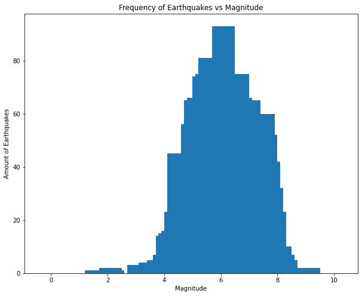

```python
# Frequency Distribution of Magnitude

# amount of data per magnitude level
frequency = dmg_mag_data['Mag'].value_counts()
# x axis - magnitude
mags = np.arange(0, 100)


plt.figure(num = 1, figsize = (10, 8))
for x in mags:
  # there isn't a record at a certain magnitude, then there won't
  # be an index for it. Therefore we add in with amount = 0
  if (x / 10) not in frequency.index:
    frequency[(x / 10)] = 0
# sort the amount not by largest, but by index (magnitude)
frequency.sort_index(ascending = True, inplace = True)
# drop the missing values column with magnitude = -1
frequency = frequency.drop(-1)

plt.bar(mags / 10.0, frequency)
plt.xlabel('Magnitude')
plt.ylabel('Amount of Earthquakes')
plt.title("Frequency of Earthquakes vs Magnitude")
plt.show()
```

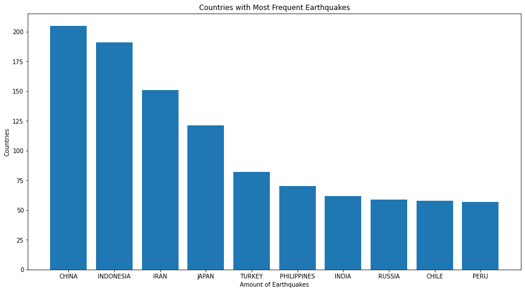

```python
# Frequency Distribution of Countries

# get the number of earthquakes per country
frequency = dmg_mag_data['Country'].value_counts()

# plotting
plt.figure(num = 2, figsize = (15, 8))
# top 10 frequent countries
plt.bar(frequency.index[:10], frequency[:10])
plt.xlabel('Amount of Earthquakes')
plt.ylabel('Countries')
plt.title("Countries with Most Frequent Earthquakes")
plt.show()
```

### Frequency of Earthquakes per Year

This plot shows how the number of earthquakes per year have changed over time. You can see that prior to 2000, the number of earthquakes were on average around 30 earthquakes while after 2000 the number of earthquakes nearly doubled per year. Possible explanations could be due to climate change, or improvements in technology detecting earthquakes.

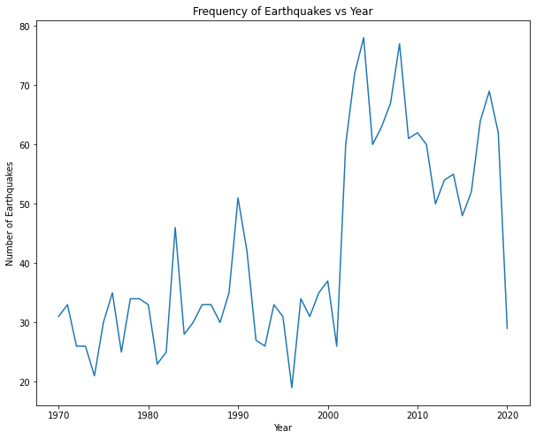

```python
# Frequency Distribution over the years

# get the amount of earthquakes per year
frequency = time_data['Year'].value_counts()

# sort by index, which will be the same result as sorting by year
frequency.sort_index(inplace = True, ascending = True)

# plotting
plt.figure(num = 3, figsize = (10, 8))
plt.plot(frequency.index, frequency)
plt.xlabel('Year')
plt.ylabel('Number of Earthquakes')
plt.title("Frequency of Earthquakes vs Year")
plt.show()
```

### Distribution of Deaths According to Damage Levels

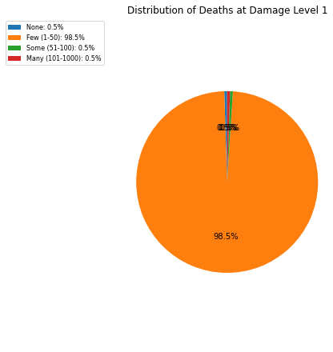

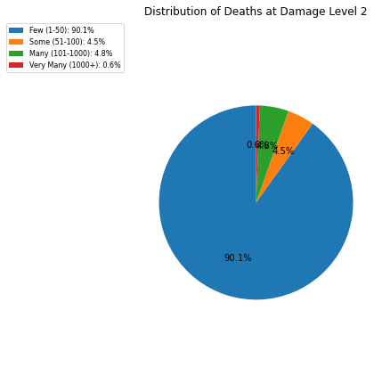

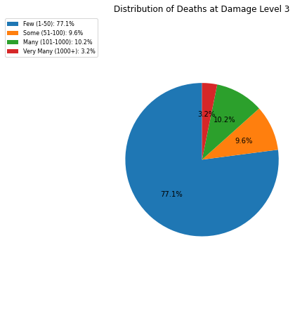

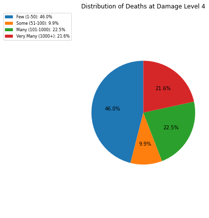

```python
# Death level proportion at each damage level using pie charts

labels = ['None', 'Few (1-50)', 'Some (51-100)', 'Many (101-1000)', 'Very Many (1000+)']
# for each damage level
for damage_level in range(1, 5):
  plt.figure(num = damage_level + 3, figsize = (6, 6))
  matching = []
  sizes = dmg_mag_data[dmg_mag_data['Damage Description'] == damage_level].value_counts('Death Description')

  # check if the label is used as index
  # if yes, it indicates that there is at least one record with this death level
  # at the according damage level
  for label in range(5):
    if label in sizes.index:
      matching.append(labels[label])

  # sort by index = sort by damage level
  sizes.sort_index(inplace = True, ascending = True)
  # drop the missing values
  sizes = sizes.drop(-1)

  # plotting
  patches, textes, _ = plt.pie(sizes, autopct='%1.1f%%', startangle = 90)
  plt.axis('equal')  # Equal aspect ratio ensures that pie is drawn as a circle.

  # legend label text
  matching = [f"{matching[i]}: {(100 * sizes[sizes.index[i]] / sum(sizes)):1.1f}%" for i in range(len(matching))]
  plt.legend(patches, matching, bbox_to_anchor=(-0.1, 1.),
           fontsize=8)
  plt.tight_layout()
  plt.title(f'Distribution of Deaths at Damage Level {damage_level}')
  plt.show()
```

### Injuries and Deaths versus Damage

This plot graphs the number of injuries and deaths per damage level and also shows the ratio of injuries and deaths for those levels. In all of damage levels, there were more injuries than deaths, yet the ratio between the injuries and deaths increases as the damage level goes up. This indicates that the death level increases slower than injuries level.

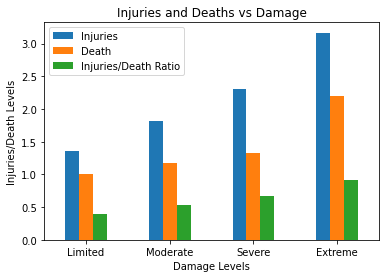

```python
# Relationship between injuries, deaths, and Damage

# injuries & death frequency
inj_dea_frequency = dmg_mag_data[['Damage Description', 'Injuries Description', 'Death Description']]
# drop all the rows with missing data in these columns
inj_dea_frequency = inj_dea_frequency[inj_dea_frequency['Injuries Description'] >= 0]
inj_dea_frequency = inj_dea_frequency[inj_dea_frequency['Death Description'] >= 0]
inj_dea_frequency = inj_dea_frequency[inj_dea_frequency['Damage Description'] >= 0]
# group by damage levels, and the average out the injuries & deaths levels at each damage level
inj_dea_frequency = inj_dea_frequency.groupby(['Damage Description']).mean()

# calculate the injuries-death ratio
inj_dea_frequency['Ratio'] = inj_dea_frequency['Injuries Description']
for i, row in inj_dea_frequency.iterrows():
  inj_dea_frequency['Ratio'] /= row['Death Description']

# plotting
inj_dea_frequency.plot(kind = 'bar', rot = 0)
plt.xticks(range(4), ['Limited', 'Moderate', 'Severe', 'Extreme'])
plt.xlabel('Damage Levels')
plt.ylabel('Injuries/Death Levels')
plt.legend(['Injuries', 'Death', 'Injuries/Death Ratio'])
plt.title("Injuries and Deaths vs Damage")
plt.show()

# it's not hard to see that injuries/death ratio is going up as damage level increases
```

### Damage Levels vs Magnitude

This plot shows how the damage levels change as the magnitude changes. There is an increasing linear trench that indicates that the damage level increases as the magnitude increases. The peak to the far left appears to be an outlier.

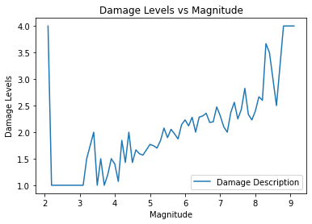

```python
# Relationship between magnitude and damage levels

dmg_data = dmg_mag_data[['Damage Description', 'Mag']]
# drop the rows with missing values in these columns
dmg_data = dmg_data[dmg_data['Damage Description'] >= 0]
dmg_data = dmg_data[dmg_data['Mag'] >= 0]
# group by magnitude, and then get the average damage level per magnitude
inj_dea_frequency = dmg_data.groupby(['Mag']).mean()
inj_dea_frequency.plot(rot = 0)

# plotting
plt.xlabel('Magnitude')
plt.ylabel('Damage Levels')
plt.title("Damage Levels vs Magnitude")
plt.show()
```

## Machine Learning and Hypothesis Testing

Our linear regression models are testing the following questions:  
How is the magnitude related with the amount of damage?  
How are the frequency of earthquakes changing over time (Years)?  
How do earthquake damage change over time (Years)?  
How do earthquake deaths change over time (Years)?  
How do earthquake injuries change over time (Years)?  
How has magnitude intensity changed over time(Years)?

```python
# function that runs linear regression & prints plot with statistics
def lin_reg(x, y):
  # a random_state is set for stablized accuracy score; is optional
  x_train, x_test, y_train, y_test = train_test_split(x, y, random_state=10)

  # create the linear regression model
  lin_model = linear_model.LinearRegression()

  # fit the training data
  lin_model.fit(x_train, y_train)

  # get the predictions based on the test set after fitting model
  y_prediction = lin_model.predict(x_test)

  # figure out the r^2 score, the slope, and intercept of the linear regression created by the model
  print(f'Accuracy of trained model matching the ground truth (R^2): {lin_model.score(x_test, y_test)}')
  print(f"Model's coefficient is: {lin_model.coef_[0]}")
  print(f"Model's intercept is: {lin_model.intercept_}")

  # return the test set input and the predicted values
  return x_test, y_prediction
```

### Damage level vs Magnitude

The regression line tests to see how the damage level changes with the magnitude. The damage levels range from 1 to 4 and are defined above where the variables are introduced. From our data our regression line is y = 0.25886611x + 0.64002416 and there is a r^2 value of 0.6320109686507254 which indicates that there is a positive correlation that more damage is done when there is a higher magnitude. However this is not a significant trend line as its absolute value is not that close to 1. In conclusion, there is a positive link between damage and magnitude. As the magnitude increases, the amount of damage increases as well.

```
Accuracy of trained model matching the ground truth (R^2): 0.6320109686507254
Model's coefficient is: [0.25886611]
Model's intercept is: [0.64002416]
```

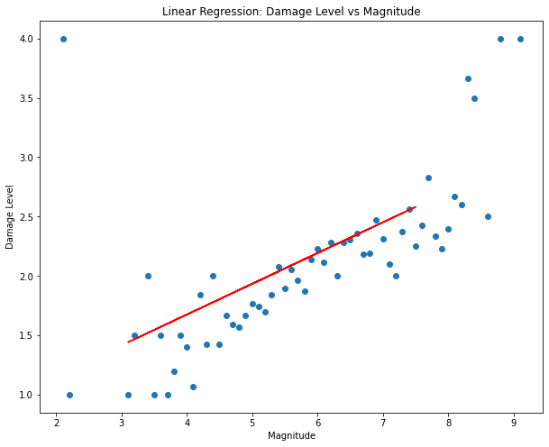

```python
# linear regression: damage level versus magnitude

# get the magnitudes and then make it into a dataframe to match input type of
# the lin_reg function.
mags = pd.DataFrame(inj_dea_frequency.index, columns = ['Mag'])

x_test, y_prediction = lin_reg(mags[['Mag']], inj_dea_frequency[['Damage Description']])

# plotting
plt.figure(num = 8, figsize = (10, 8))
plt.title('Linear Regression: Damage Level vs Magnitude')
plt.xlabel('Magnitude')
plt.ylabel('Damage Level')
plt.scatter(mags[['Mag']], inj_dea_frequency[['Damage Description']])
plt.plot(x_test, y_prediction, color = 'red')
plt.show()
```

### Frequency of Earthquakes over time (Years)

This is the linear regression model that measures how the number of earthquakes change over time in years. The calculated linear regression model is y = 0.7294470011505175X + (-1413.755421189535) and the r<sup>2</sup> value is 0.47002197213084895

```
Accuracy of trained model matching the ground truth (R^2): 0.47002197213084895
Model's coefficient is: 0.7294470011505175
Model's intercept is: -1413.755421189535
```

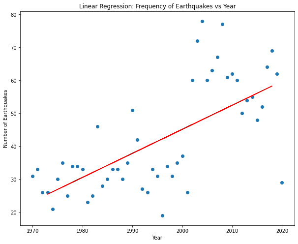

```python
# amount of earthquakes over the years

# get the amount of earthquakes per year, and sort by year
frequency = time_data['Year'].value_counts()
frequency.sort_index(inplace = True, ascending = True)

# get the years and then make it into a dataframe to match input type of
# the lin_reg function.
years = pd.DataFrame(time_data['Year'].unique(), columns = ['Year'])

x_test, y_prediction = lin_reg(years[['Year']], frequency)

# plotting
plt.figure(num = 9, figsize = (10, 8))
plt.title('Linear Regression: Frequency of Earthquakes vs Year')
plt.xlabel('Year')
plt.ylabel('Number of Earthquakes')
plt.scatter(years[['Year']], frequency)
plt.plot(x_test, y_prediction, color = 'red')
plt.show()
```

### Average Damage, Injuries and Deaths per Year

Lastly, the green data points and regression line represent the deaths that occured over the years. The calculated regression line is Y = -0.0082716X + 17.90497595 and the correlation coefficient r<sup>2</sup> is 0.25804961207832433. This is shown to have a negative correlation, meaning that the number of deaths have been decreasing. However, the correlation coefficient is not high meaning that this model is not very accurate. This could be due to faulty dataset.

From these three parameters, they all have a negative correlation however do not have a convincing correlation coefficient. This could potentially be due to the dataset not having a large enough sample to have an accurate prediction, or due to a change in the data collection methods over the years. If these models all have correlation coefficients close to one, it would mean that human response to earthquake intervention has improved. Examples of this could be having more explicit protocols for earthquake responses to increase safety, improved structural engineering which makes buildings more resistant to earthquakes, improved medical procedures to treat injured victims or more.

```
Damage Description:
Accuracy of trained model matching the ground truth (R^2): 0.12167200106992637
Model's coefficient is: [-0.0058536]
Model's intercept is: [13.79629366]

Injuries Description:
Accuracy of trained model matching the ground truth (R^2): 0.1746699066819657
Model's coefficient is: [-0.00997791]
Model's intercept is: [21.82645275]

Death Description:
Accuracy of trained model matching the ground truth (R^2): 0.25804961207832433
Model's coefficient is: [-0.0082716]
Model's intercept is: [17.90497595]
```

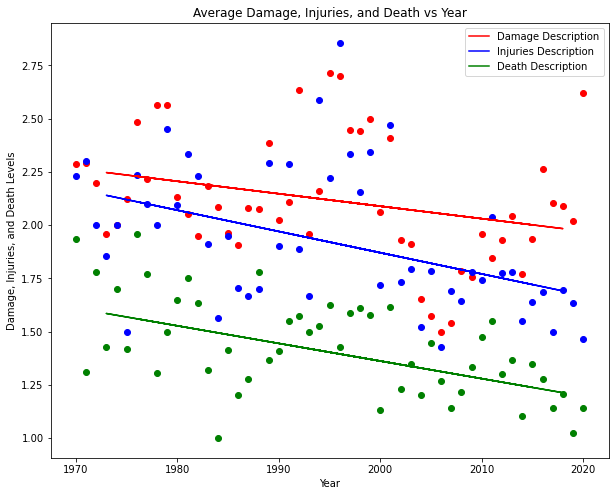

```python
# different damage measurements over the years

# different measurements we will look into
measurements = ['Damage Description', 'Injuries Description', 'Death Description']
colors = ['red', 'blue', 'green']

# get values and plot for each measurement
for x in range(3):
  avg_dmg_year_data = dmg_mag_data[['Year', measurements[x]]]
  # drop the rows with missing value in the column
  avg_dmg_year_data = avg_dmg_year_data[avg_dmg_year_data[measurements[x]] >= 0]
  # group by year, then get the average level of measurement per year
  avg_dmg_year_data = avg_dmg_year_data.groupby('Year').mean()

  print(f'{measurements[x]}:')
  x_test, y_prediction = lin_reg(years[['Year']], avg_dmg_year_data[[measurements[x]]])
  print('')

  # plotting
  plt.figure(num = 10, figsize = (10, 8))
  plt.scatter(years[['Year']], avg_dmg_year_data[[measurements[x]]], color = colors[x])
  plt.plot(x_test, y_prediction, color = colors[x])

# plotting
plt.legend(measurements)
plt.title(f'Average Damage, Injuries, and Death vs Year')
plt.xlabel('Year')
plt.ylabel('Damage, Injuries, and Death Levels')
plt.show()
```

### Average Magnitude Over Time (Years)

Connecting to the 3 linear regrssion graphs from above, we can tell that the injuries and death levels are decreasing at faster rates compared to that of magnitude. This implies a growth in solutions for earthquakes, yet damage level is decreasing at a lower rate than that of magnitude. This could potentially be due to the fact that we are constructing more and more facilities and building, which tend to cost more. Since damage level is measured by the rough amount of money lost, it may be reasonable to see a slower decline of damage levels in the future as well.

```
Accuracy of trained model matching the ground truth (R^2): 0.347173994598746
Model's coefficient is: [-0.0073966]
Model's intercept is: [20.90171459]
```

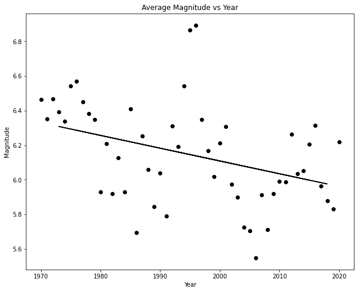

```python
# average magnitude over the years

avg_dmg_year_data = dmg_mag_data[['Year', 'Mag']]
# drop the rows with missing value in magnitude
avg_dmg_year_data = avg_dmg_year_data[avg_dmg_year_data['Mag'] >= 0]
# group by year, then get the average magnitude per year
avg_stuff = avg_dmg_year_data.groupby('Year').mean()

x_test, y_prediction = lin_reg(years[['Year']], avg_stuff[['Mag']])

# plotting
plt.figure(num = 11, figsize = (10, 8))
plt.scatter(years[['Year']], avg_stuff[['Mag']], color = 'black')
plt.plot(x_test, y_prediction, color = 'black')
plt.title(f'Average Magnitude vs Year')
plt.xlabel('Year')
plt.ylabel('Magnitude')
plt.show()
```

# Additional Resources

More reading and references about earthquakes can be found here:

1) How climate change is affecting natural disasters:  
2) [How Climate Affects Earthquakes](https://climate.nasa.gov/news/2926/can-climate-affect-earthquakes-or-are-the-connections-shaky/)  
3) [Predicting Earthquakes](https://www.usgs.gov/faqs/can-you-predict-earthquakes)  
4) [10 most destructive earthquakes in history](https://geologyscience.com/applied-geology/natural-hazards/10-most-powerful-earthquakes-in-earth-history/)